# Loan Eligibility: Visualizations

Jake Bersabe

02/11/2021

Let’s start by importing the data set.

```r
library(dplyr)
data <- read.csv("train.csv")
```

```r
glimpse(data)
```

```
## Rows: 614
## Columns: 13
## $ ï..Loan_ID        <chr> "LP001002", "LP001003", "LP001005", "LP001006", "LP0~
## $ Gender            <chr> "Male", "Male", "Male", "Male", "Male", "Male", "Mal~
## $ Married           <chr> "No", "Yes", "Yes", "Yes", "No", "Yes", "Yes", "Yes"~
## $ Dependents        <int> 0, 1, 0, 0, 0, 2, 0, 3, 2, 1, 2, 2, 2, 0, 2, 0, 1, 0~
## $ Education         <chr> "Graduate", "Graduate", "Graduate", "Not Graduate", ~
## $ Self_Employed     <chr> "No", "No", "Yes", "No", "No", "Yes", "No", "No", "N~
## $ ApplicantIncome   <int> 5849, 4583, 3000, 2583, 6000, 5417, 2333, 3036, 4006~
## $ CoapplicantIncome <dbl> 0, 1508, 0, 2358, 0, 4196, 1516, 2504, 1526, 10968, ~
## $ LoanAmount        <int> NA, 128, 66, 120, 141, 267, 95, 158, 168, 349, 70, 1~
## $ Loan_Amount_Term  <int> 360, 360, 360, 360, 360, 360, 360, 360, 360, 360, 36~
## $ Credit_History    <int> 1, 1, 1, 1, 1, 1, 1, 0, 1, 1, 1, 1, 1, 1, 1, 1, NA, ~
## $ Property_Area     <chr> "Urban", "Rural", "Urban", "Urban", "Urban", "Urban"~
## $ Loan_Status       <chr> "Y", "N", "Y", "Y", "Y", "Y", "Y", "N", "Y", "N", "Y~
```

### Visualizations

Through visual reports, let us explore the data and see if relationships can be found between the variables. Our focus will be on the target variable - Loan_Status.

#### 1. Gender and Loan Status

```r
data %>%
  filter(Gender != "") %>%
  group_by(Gender, Loan_Status) %>%
  summarise(Count=n()) %>%
  mutate(Percentage=paste(round(Count*100/sum(Count),1),"%"))
```

```
## # A tibble: 4 x 4
## # Groups:   Gender [2]
##   Gender Loan_Status Count Percentage
##   <chr>  <chr>       <int> <chr>
## 1 Female N              37 33 %
## 2 Female Y              75 67 %
## 3 Male   N             150 30.7 %
## 4 Male   Y             339 69.3 %
```

After removing the missing values, the data frame was then grouped by Gender and Loan_Status and summarized to give the count of each row entry and the corresponding percentages. The resulting data frame was then graphed to visualize the comparison. Similar approach will be applied in the succeeding items.

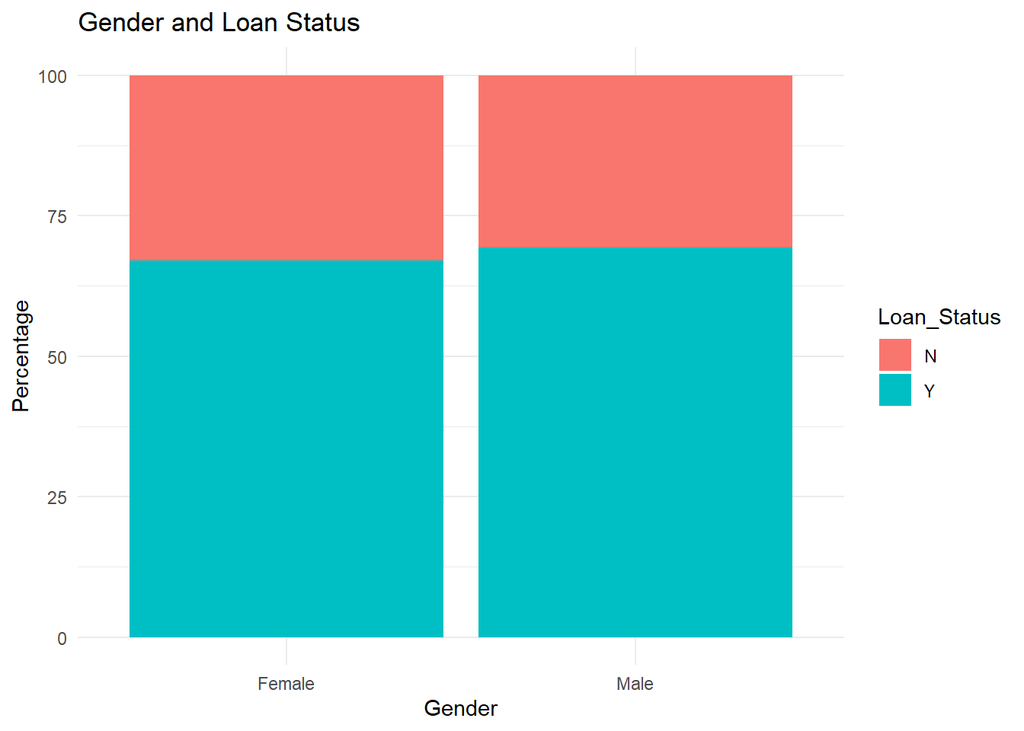

```r
library(ggplot2)
data %>%
  filter(Gender != "") %>%
  group_by(Gender, Loan_Status) %>%
  summarise(Count=n()) %>%
  mutate(Percentage=round(Count*100/sum(Count),1)) %>%
  ggplot(aes(x=Gender,y=Percentage,fill=Loan_Status))+
  geom_col(position = "stack")+
  theme_minimal()+
  ggtitle("Gender and Loan Status")+
  scale_y_continuous(limits = c(0,100))
```

> *Roughly equal distribution of loan approval and disapproval across the genders.*

#### 2. Civil Status and Loan Status

```r
data %>%
  filter(Married != "") %>%
  group_by(Married, Loan_Status) %>%
  summarise(Count=n()) %>%
  mutate(Percentage=paste(round(Count*100/sum(Count),1),"%"))
```

```
## # A tibble: 4 x 4
## # Groups:   Married [2]
##   Married Loan_Status Count Percentage
##   <chr>   <chr>       <int> <chr>
## 1 No      N              79 37.1 %
## 2 No      Y             134 62.9 %
## 3 Yes     N             113 28.4 %
## 4 Yes     Y             285 71.6 %
```

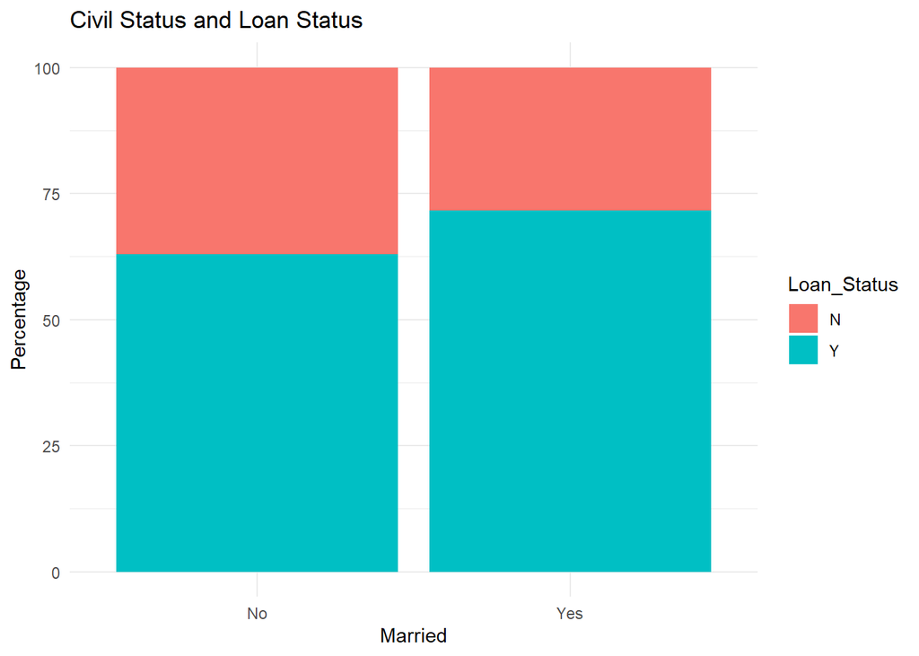

> *More married applicants are approved and less married applicants are disapproved than unmarried applicants.*

#### 3. Number of Dependents and Loan Status

```r
data %>%
  filter(Dependents != "") %>%
  group_by(Dependents, Loan_Status) %>%
  summarise(Count=n()) %>%
  mutate(Percentage=paste(round(Count*100/sum(Count),1),"%"))
```

```
## # A tibble: 8 x 4
## # Groups:   Dependents [4]
##   Dependents Loan_Status Count Percentage
##        <int> <chr>       <int> <chr>
## 1          0 N             107 31 %
## 2          0 Y             238 69 %
## 3          1 N              36 35.3 %
## 4          1 Y              66 64.7 %
## 5          2 N              25 24.8 %
## 6          2 Y              76 75.2 %
## 7          3 N              18 35.3 %
## 8          3 Y              33 64.7 %
```

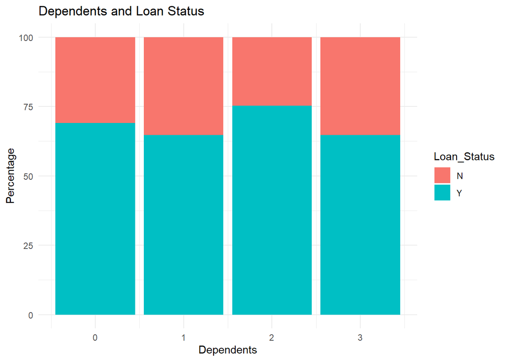

> *Highest approval and lowest loan disapproval in the applicants with two dependents.*

#### 4. Educational Background and Loan Status

```r
data %>%
  group_by(Education, Loan_Status) %>%
  summarise(Count=n()) %>%
  mutate(Percentage=paste(round(Count*100/sum(Count),1),"%"))
```

```
## # A tibble: 4 x 4
## # Groups:   Education [2]
##   Education    Loan_Status Count Percentage
##   <chr>        <chr>       <int> <chr>
## 1 Graduate     N             140 29.2 %
## 2 Graduate     Y             340 70.8 %
## 3 Not Graduate N              52 38.8 %
## 4 Not Graduate Y              82 61.2 %
```

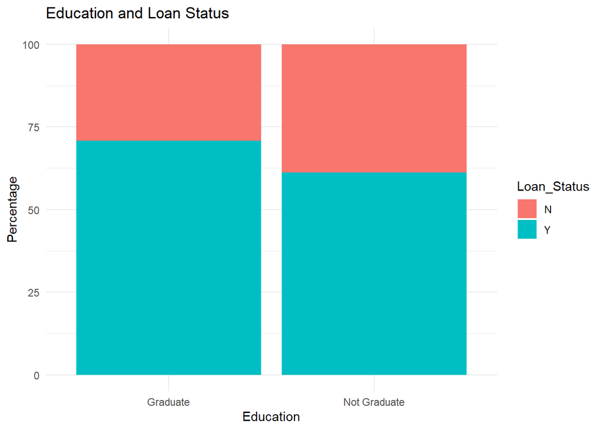

```r
data %>%
  group_by(Education, Loan_Status) %>%
  summarise(Count=n()) %>%
  mutate(Percentage=round(Count*100/sum(Count),1)) %>%
  ggplot(aes(x=Education, y=Percentage, fill=Loan_Status))+
  geom_col(position = "stack")+
  theme_minimal()+
  ggtitle("Education and Loan Status")+
  scale_y_continuous(limits = c(0,100))
```

> *Graduate applicants are getting more loan approvals.*

#### 5. Self-employment and Loan Status

```r
data %>%
  filter(Self_Employed != "") %>%
  group_by(Self_Employed, Loan_Status) %>%
  summarise(Count=n()) %>%
  mutate(Percentage=round(Count*100/sum(Count),1))
```

```
## # A tibble: 4 x 4
## # Groups:   Self_Employed [2]
##   Self_Employed Loan_Status Count Percentage
##   <chr>         <chr>       <int>      <dbl>
## 1 No            N             157       31.4
## 2 No            Y             343       68.6
## 3 Yes           N              26       31.7
## 4 Yes           Y              56       68.3
```

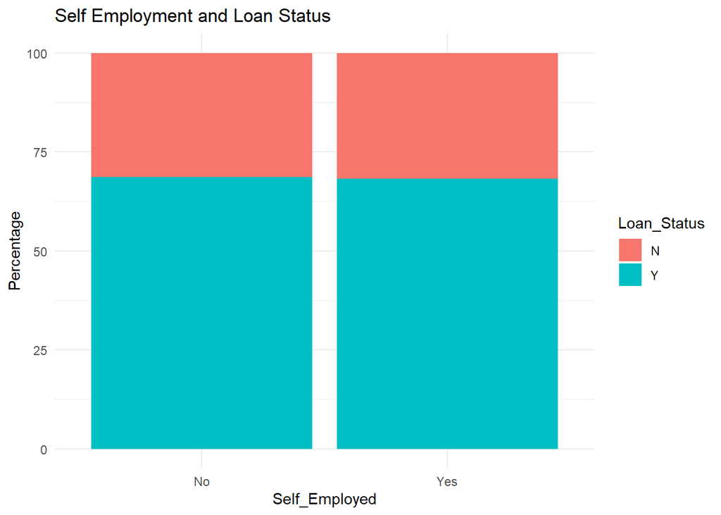

> *Almost equal distribution of approved and disapproved loans across the self-employed and not self-employed applicants.*

#### 6. Loan Amount and Loan Status

First, let us check the distribution of data.

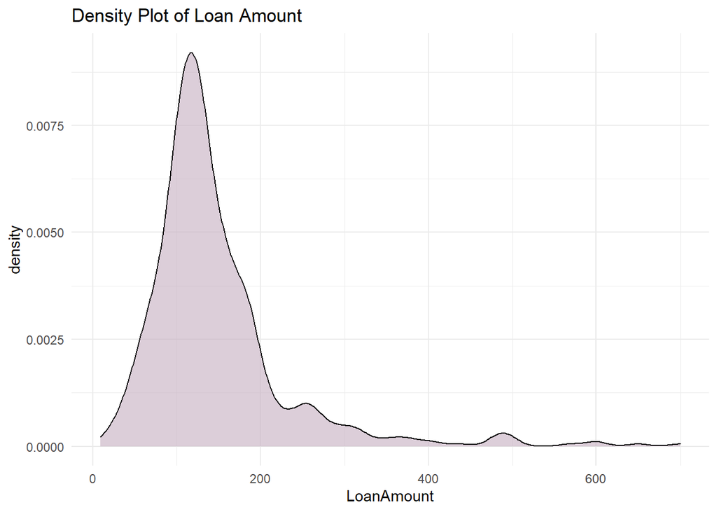

```r
data %>%
  filter(LoanAmount != "") %>%
  ggplot(aes(x=LoanAmount))+
  geom_density(fill="#C4ADBF",alpha=0.6)+
  theme_minimal()+
  ggtitle("Density Plot of Loan Amount")
```

> *The distribution of loan amount is right-skewed due to outliers. We need to perform logarithmic transformation to deal with the outliers.*

```r
data %>%
  filter(LoanAmount != "") %>%
  group_by(Loan_Status) %>%
  summarise(Count = n(),
            MeanLoanAmount=mean(LoanAmount*1000) %>% round(2))
```

```
## # A tibble: 2 x 3
##   Loan_Status Count MeanLoanAmount
##   <chr>       <int>          <dbl>
## 1 N             181        151221.
## 2 Y             411        144294.
```

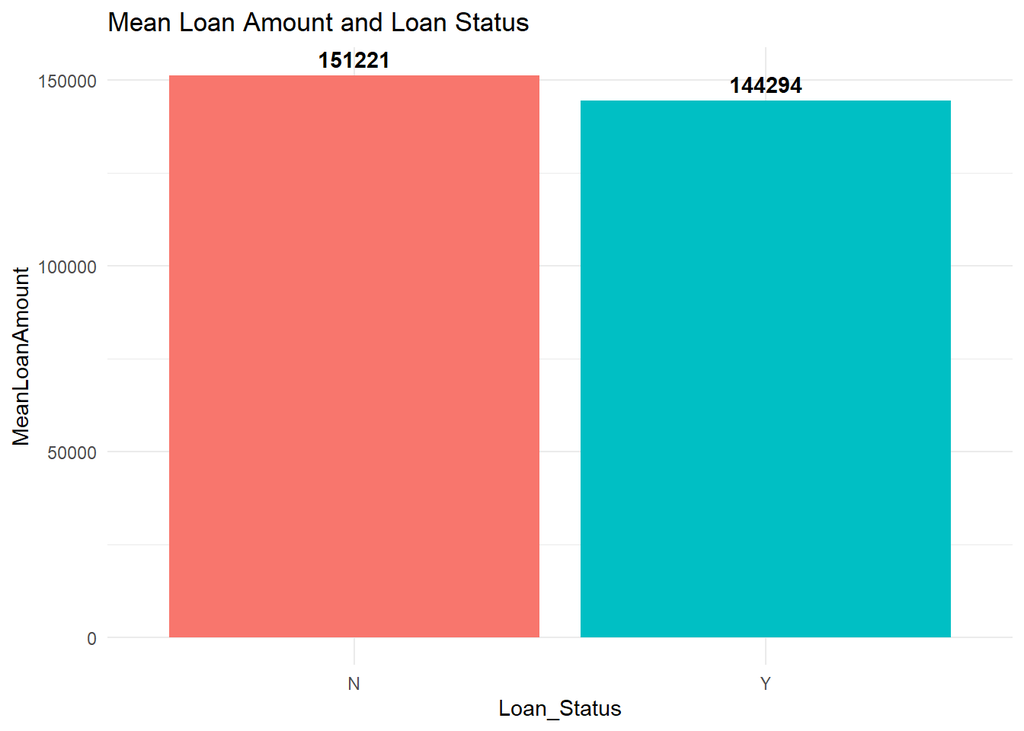

```r
data %>%
  filter(LoanAmount != "") %>%
  group_by(Loan_Status) %>%
  summarise(Count = n(),
            MeanLoanAmount=mean(LoanAmount*1000) %>% round(0)) %>%
  ggplot(aes(x=Loan_Status, y=MeanLoanAmount))+
  theme_minimal()+
  geom_col(fill=c("#F8766D","#00BFC4"))+
  geom_text(aes(label=MeanLoanAmount), vjust = -0.5, fontface = "bold")+
  ggtitle("Mean Loan Amount and Loan Status")
```

#### 7. Applicant Income and Loan Status

Again, let us check the distribution.

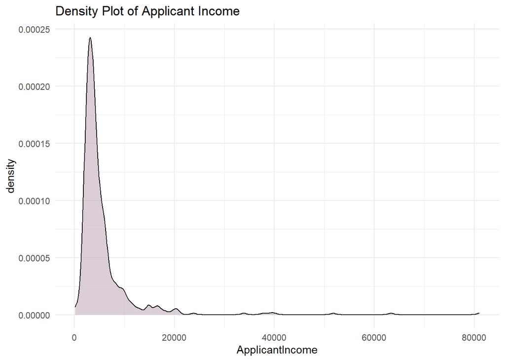

```r
data %>%
  ggplot(aes(x=ApplicantIncome))+
  geom_density(fill="#C4ADBF",alpha=0.6)+
  theme_minimal()+
  ggtitle("Density Plot of Applicant Income")
```

> *Just like the loan amount, the distribution of applicant income is right-skewed too. Proceed with logarithmic transformation.*

```r
data %>%
  group_by(Loan_Status) %>%
  summarise(Count = n(),
            MeanApplicantIncome=mean(ApplicantIncome) %>%
              round(2))
```

```
## # A tibble: 2 x 3
##   Loan_Status Count MeanApplicantIncome
##   <chr>       <int>               <dbl>
## 1 N             192               5446.
## 2 Y             422               5384.
```

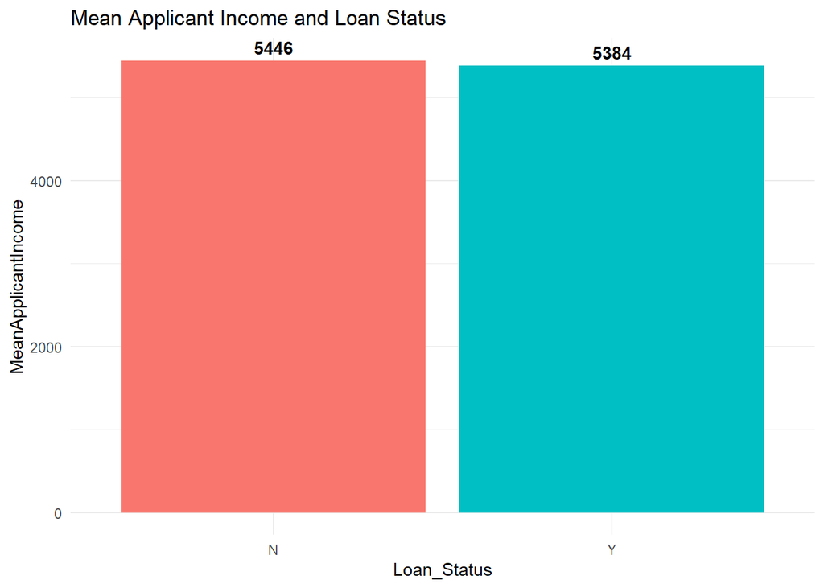

```r
data %>%
  group_by(Loan_Status) %>%
  summarise(Count = n(),
            MeanApplicantIncome=mean(ApplicantIncome) %>%
              round(0)) %>%
  ggplot(aes(x = Loan_Status, y = MeanApplicantIncome))+
  geom_col(fill=c("#F8766D","#00BFC4"))+
  theme_minimal()+
  geom_text(aes(label=MeanApplicantIncome), vjust = -0.5, fontface = "bold")+
  ggtitle("Mean Applicant Income and Loan Status")
```

#### 8. Co-applicant Income and Loan Status

Again, let us check the distribution.

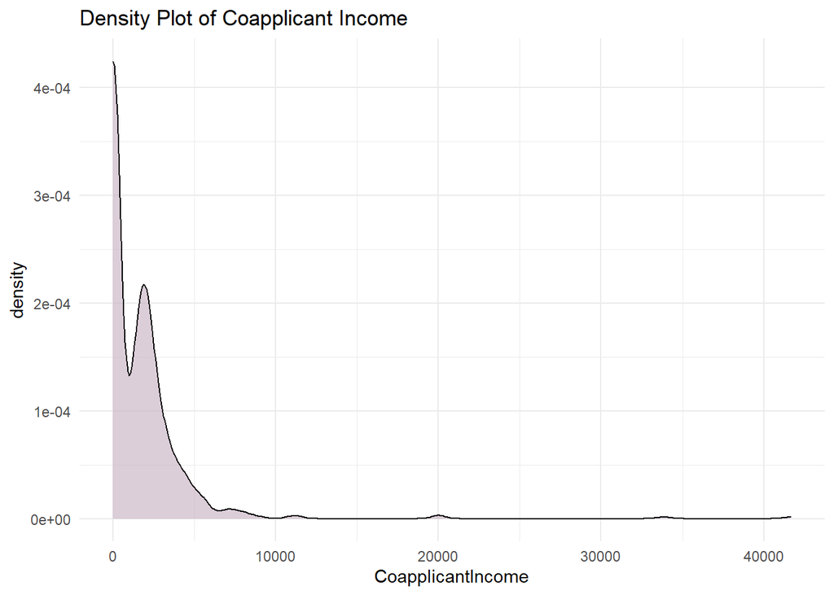

```r
data %>%
  ggplot(aes(x=CoapplicantIncome))+
  geom_density(fill="#C4ADBF",alpha=0.6)+
  theme_minimal()+
  ggtitle("Density Plot of Coapplicant Income")
```

> *The distribution of the co-applicant income is right-skewed and bi-modal.*

```r
data %>%
  group_by(Loan_Status) %>%
  summarise(Count = n(),
            MeanCoapplicantIncome=mean(CoapplicantIncome) %>%  round(2))
```

```
## # A tibble: 2 x 3
##   Loan_Status Count MeanCoapplicantIncome
##   <chr>       <int>                 <dbl>
## 1 N             192                 1878.
## 2 Y             422                 1505.
```

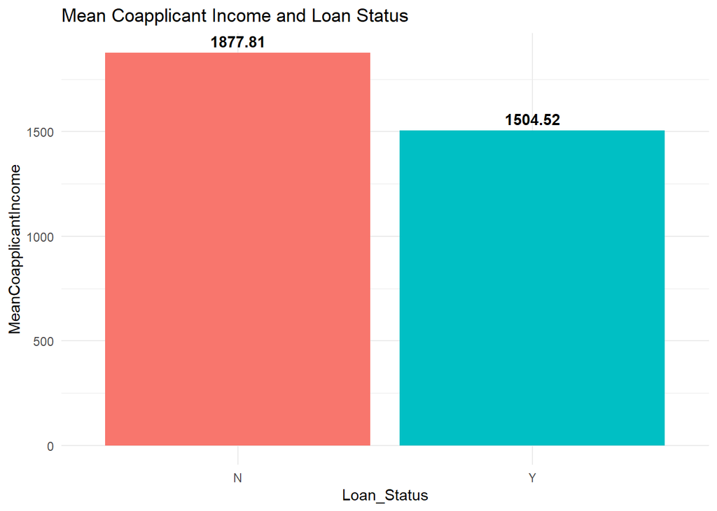

```r
data %>%
  group_by(Loan_Status) %>%
  summarise(Count = n(),
            MeanCoapplicantIncome=mean(CoapplicantIncome) %>% round(2)) %>%
  ggplot(aes(x = Loan_Status, y = MeanCoapplicantIncome))+
  geom_col(fill=c("#F8766D","#00BFC4"))+
  geom_text(aes(label=MeanCoapplicantIncome), vjust = -0.5, fontface = "bold")+
  ggtitle("Mean Coapplicant Income and Loan Status")+
  theme_minimal()
```

#### 9. Loan Amount Term and Loan Status

```r
data %>%
  filter(Loan_Amount_Term != "") %>%
  mutate(Loan_Amount_Term = factor(Loan_Amount_Term),
         Loan_Amount_Term = forcats::fct_lump(Loan_Amount_Term, n = 3)) %>%
  group_by(Loan_Amount_Term,Loan_Status) %>%
  summarise(Count=n()) %>%
  mutate(Percentage  = paste(round(Count*100/sum(Count),1),"%"))
```

```
## # A tibble: 8 x 4
## # Groups:   Loan_Amount_Term [4]
##   Loan_Amount_Term Loan_Status Count Percentage
##   <fct>            <chr>       <int> <chr>
## 1 180              N              15 34.1 %
## 2 180              Y              29 65.9 %
## 3 360              N             153 29.9 %
## 4 360              Y             359 70.1 %
## 5 480              N               9 60 %
## 6 480              Y               6 40 %
## 7 Other            N               9 31 %
## 8 Other            Y              20 69 %
```

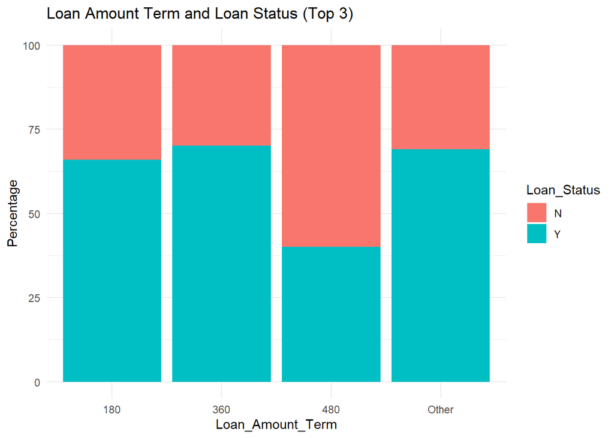

> *480 months loan amount term has the lowest loan approval and the highest loan disapproval.*

#### 10. Credit History and Loan Status

[output not shown]

[figure not shown]

```r
data %>%
  filter(Credit_History != "") %>%
  group_by(Credit_History,Loan_Status) %>%
  summarise(Count=n()) %>%
  mutate(Percentage  = paste(round(Count*100/sum(Count),1),"%"))
```

> *Applicants with no credit history have the higher loan disapproval rate and applicants with credit history have higher loan approval rate.*

#### 11. Property Area and Loan Status

```r
data %>%
  group_by(Property_Area,Loan_Status) %>%
  summarise(Count=n()) %>%
  mutate(Percentage  = paste(round(Count*100/sum(Count),1),"%"))
```

```
## # A tibble: 6 x 4
## # Groups:   Property_Area [3]
##   Property_Area Loan_Status Count Percentage
##   <chr>         <chr>       <int> <chr>
## 1 Rural         N              69 38.5 %
## 2 Rural         Y             110 61.5 %
## 3 Semiurban     N              54 23.2 %
## 4 Semiurban     Y             179 76.8 %
## 5 Urban         N              69 34.2 %
## 6 Urban         Y             133 65.8 %
```

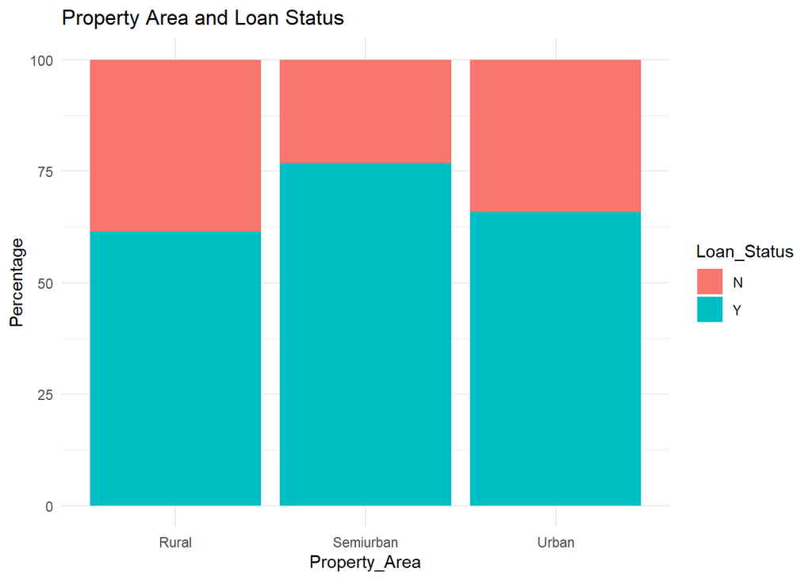

> *Semi-urban property area has the highest loan approval rate.*